# Pendugaan Parameter, Diagnostik Model, dan Peramalan

Kheni Hikmah Lestari

## Packages yang digunakakan

```r
library(ggplot2)
library(tsibble)
library(tseries)
library(MASS)
library(forecast)
library(TSA)
library(TTR)
library(aTSA)
library(graphics)
library(rio)
```

## Penyiapan Data

```r
#Input data
data = import("https://raw.githubusercontent.com/khenihikmah/praktikummpdw/main/Pertemuan1/Data%20Penumpang%20Pesawat.csv")
data
```

```
##     Month Passengers
## 1       1      13224
## 2       2      10789
## 3       3       6434
## 4       4       6433
## 5       5       4002
## 6       6       3540
## 7       7       7214
## 8       8       5294
## 9       9       4570
## 10     10       7315
## 11     11       7210
## 12     12       7801
## 13     13      10677
## 14     14      13367
```

[output cut: 118 more lines]

```r
#Mengambil data Passengers
data <- data$Passengers

#Mengubah tipe data menjadi time series
data.ts<-ts(data)
```

## Eksplorasi Data

### Plot Data Penuh

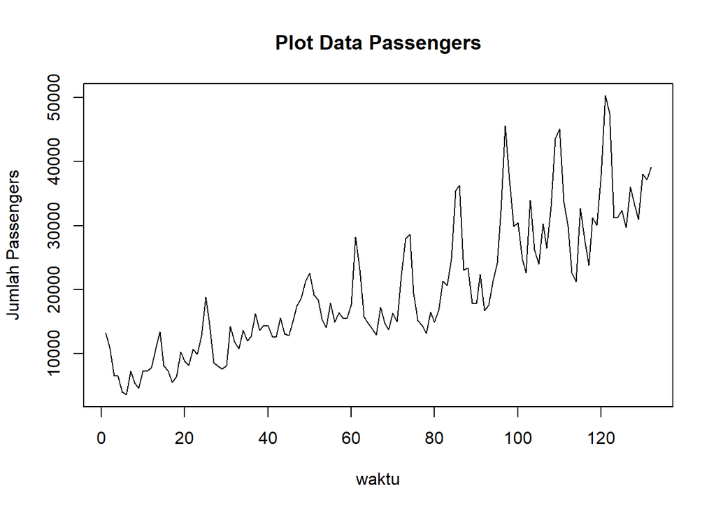

```r
plot.ts(data.ts, xlab="waktu", ylab="Jumlah Passengers", main="Plot Data Passengers")
```

Berdasarkan plot data deret waktu, terlihat bahwa data memiliki pola siklik. Berdasarkan pola data, pembagian data latih dan data uji ditetapkan dengan proporsi 80%:20%.

### Plot Data Latih

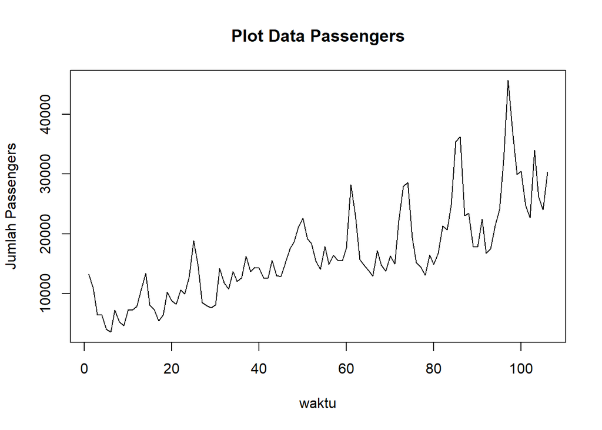

```r
datatrain<-data[1:106]
train.ts<-ts(datatrain)
plot.ts(train.ts, lty=1, xlab="waktu", ylab="Jumlah Passengers", main="Plot Data Passengers")
```

Berdasarkan plot data deret waktu pada data latih, terlihat bahwa data cenderung memiliki trend yang naik. Hal ini mengindikasikan bahwa data tidak stasioner dalam rataan.

### Plot Data Uji

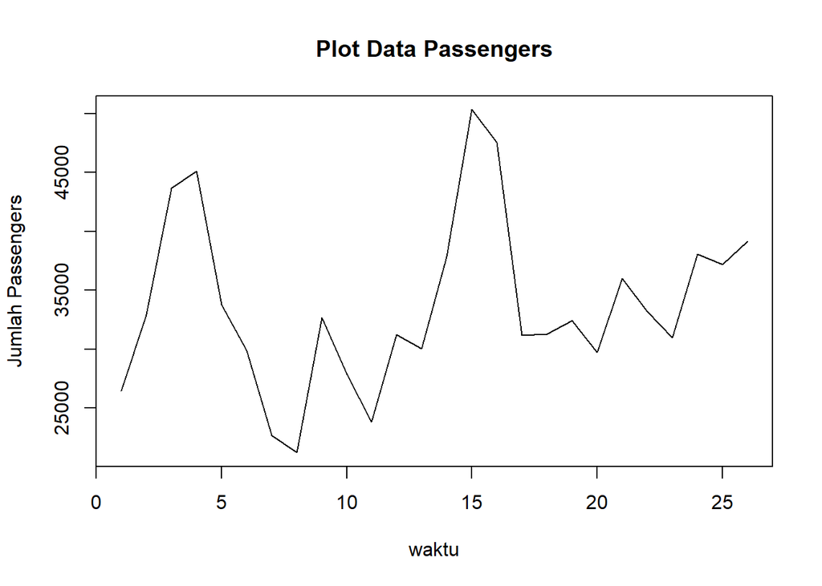

```r
datatest<-data[107:132]
test.ts<-ts(datatest)
plot.ts(test.ts, lty=1, xlab="waktu", ylab="Jumlah Passengers", main="Plot Data Passengers")
```

## Uji Stasioneritas Data

### Plot ACF

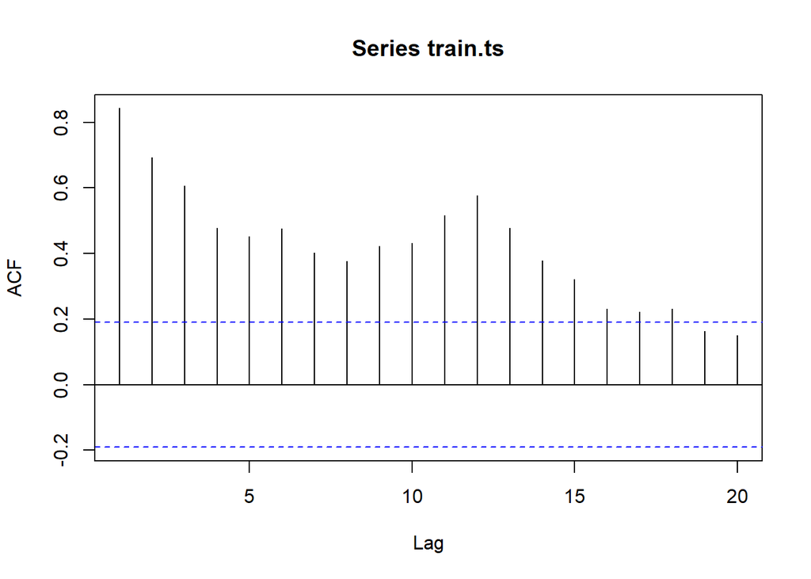

```r
acf(train.ts)
```

### Uji ADF

```r
tseries::adf.test(train.ts)
```

```
##
##  Augmented Dickey-Fuller Test
##
## data:  train.ts
## Dickey-Fuller = -4.6475, Lag order = 4, p-value = 0.01
## alternative hypothesis: stationary
```

$H_0$ : Data tidak stasioner dalam rataan

$H_1$ : Data stasioner dalam rataan

### Plot Box-Cox

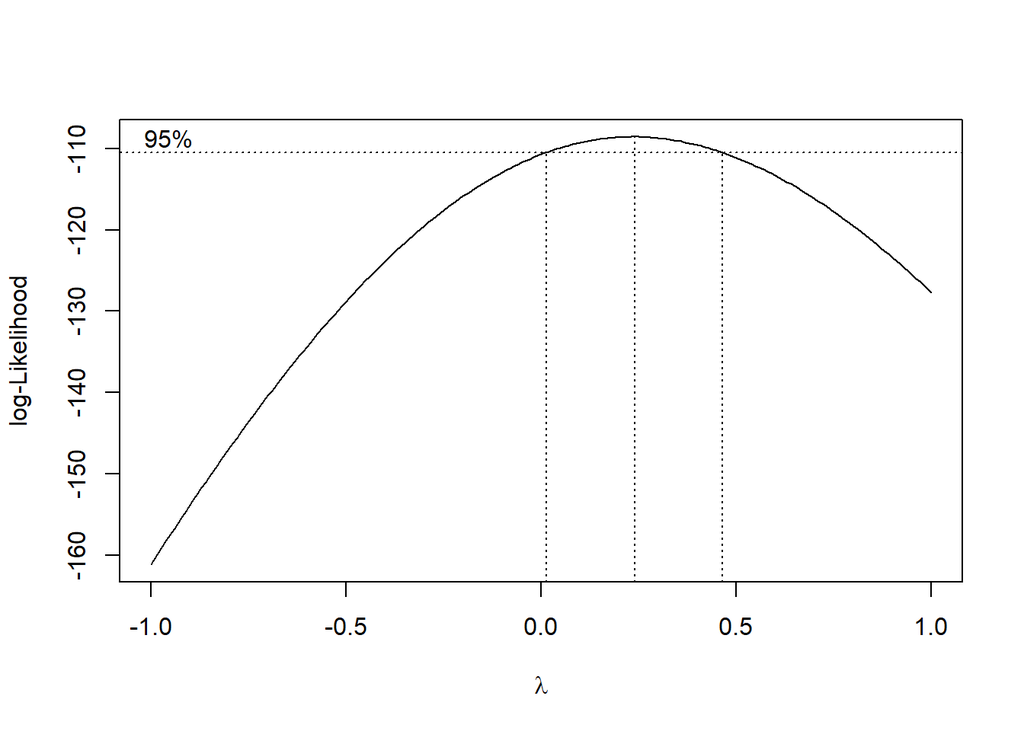

```r
index <- seq(1:106)
bc = boxcox(train.ts~index, lambda = seq(-1,1,by=0.01))
```

```r
#Nilai Rounded Lambda
lambda <- bc$x[which.max(bc$y)]
lambda
```

```
## [1] 0.24
```

```r
#SK
bc$x[bc$y > max(bc$y) - 1/2 * qchisq(.95,1)]
```

```
##  [1] 0.02 0.03 0.04 0.05 0.06 0.07 0.08 0.09 0.10 0.11 0.12 0.13 0.14 0.15 0.16
## [16] 0.17 0.18 0.19 0.20 0.21 0.22 0.23 0.24 0.25 0.26 0.27 0.28 0.29 0.30 0.31
## [31] 0.32 0.33 0.34 0.35 0.36 0.37 0.38 0.39 0.40 0.41 0.42 0.43 0.44 0.45 0.46
```

Plot Boxcox menunjukkan nilai *rounded value* ($\lambda$) optimum sebesar **0.24** dan pada selang kepercayaan 95% nilai memiliki batas bawah **0.02** dan batas atas **0.46**. Selang tersebut tidak memuat nilai satu sehingga dapat dikatakan bahwa data yang digunakan tidak stasioner dalam ragam.

## Penanganan Ketidakstasioneran Data

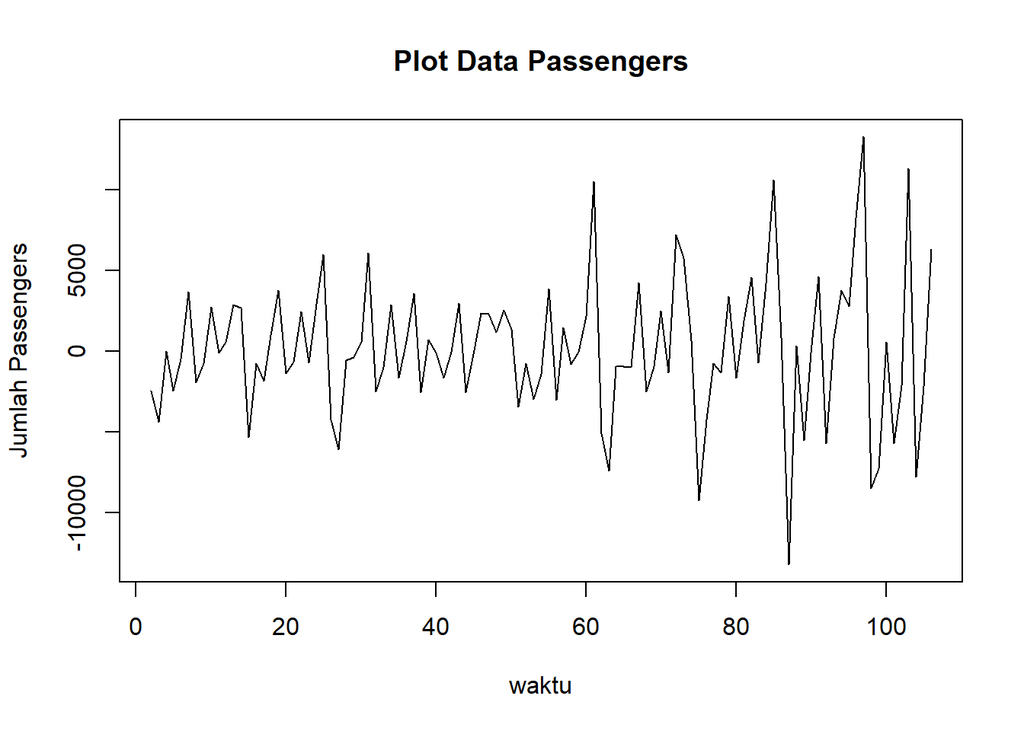

```r
train.diff<-diff(train.ts,differences = 1)
plot.ts(train.diff, lty=1, xlab="waktu", ylab="Jumlah Passengers", main="Plot Data Passengers")
```

### Plot ACF

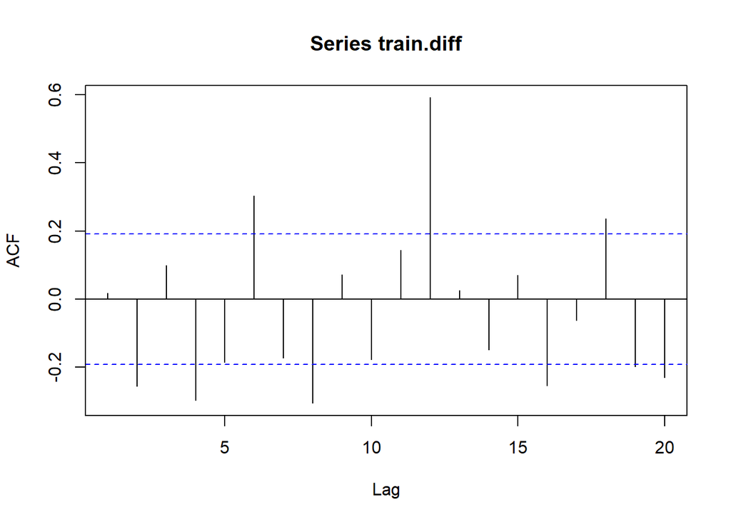

```r
acf(train.diff)
```

### Uji ADF

```r
tseries::adf.test(train.diff)
```

```
##
##  Augmented Dickey-Fuller Test
##
## data:  train.diff
## Dickey-Fuller = -6.7933, Lag order = 4, p-value = 0.01
## alternative hypothesis: stationary
```

$H_0$ : Data tidak stasioner dalam rataan

$H_1$ : Data stasioner dalam rataan

Berdasarkan uji ADF tersebut, didapat *p-value* sebesar 0.01 yang lebih kecil dari taraf nyata 5% sehingga tolak $H_0$ atau data stasioner dalam rataan. Hal ini sesuai dengan hasil eksplorasi menggunakan plot time series dan plot ACF, sehingga dalam hal ini ketidakstasioneran data sudah berhasil ditangani dan dapat dilanjutkan ke pemodelan

## Identifikasi Model

### Plot ACF

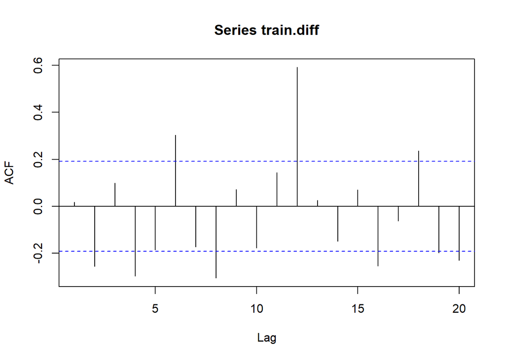

```r
acf(train.diff)
```

### Plot PACF

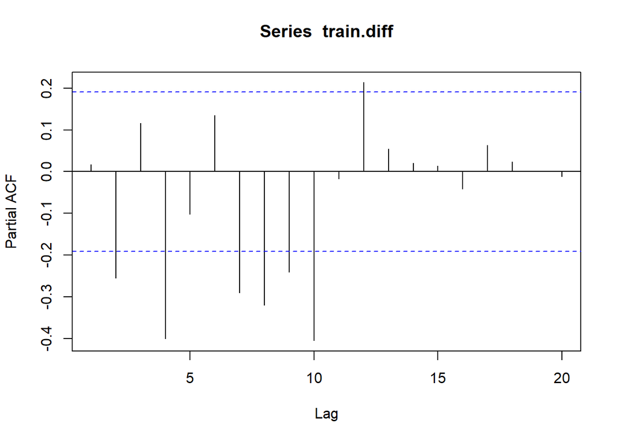

```r
pacf(train.diff)
```

Jika baik plot ACF maupun plot PACF keduanya dianggap tails of, maka model yang terbentuk adalah ARIMA(1,1,1)

### Plot EACF

```r
eacf(train.diff)
```

```
## AR/MA
##   0 1 2 3 4 5 6 7 8 9 10 11 12 13
## 0 o x o x o x o x o o o  x  o  o
## 1 o x o x o o o x o o o  x  o  o
## 2 x x o x x o x x o o o  x  x  x
## 3 x x x x o o o x o o o  x  o  o
## 4 x x x x o o o x o o o  x  x  o
## 5 x o x o x o o o o o o  o  x  o
## 6 x o x x o o o o o o o  o  o  o
## 7 x o x o o o x o o o o  o  o  o
```

Identifikasi model menggunakan plot EACF dilakukan dengan melihat ujung segitiga pada pola segitiga nol. Dalam hal ini model tentatif yang terbentuk adalah ARIMA(0,1,2), ARIMA(1,1,0), dan ARIMA(0,1,2)

## Pendugaan Parameter Model Tentatif

### ARIMA(1,1,0)

```r
model1.da=Arima(train.diff, order=c(1,1,0),method="ML")
summary(model1.da) #AIC=2093.26
```

```
## Series: train.diff
## ARIMA(1,1,0)
##
## Coefficients:
##           ar1
##       -0.3573
## s.e.   0.0920
##
## sigma^2 = 31311723:  log likelihood = -1044.63
## AIC=2093.26   AICc=2093.38   BIC=2098.55
##
## Training set error measures:
##                  ME     RMSE      MAE      MPE     MAPE      MASE       ACF1
## Training set 85.432 5542.139 4090.014 -3457.36 3766.799 0.8999882 -0.1836536
```

```r
lmtest::coeftest(model1.da) #seluruh parameter signifikan
```

```
##
## z test of coefficients:
##
##      Estimate Std. Error z value  Pr(>|z|)
## ar1 -0.357317   0.092002 -3.8838 0.0001028 ***
## ---
## Signif. codes:  0 '***' 0.001 '**' 0.01 '*' 0.05 '.' 0.1 ' ' 1
```

### ARIMA(0,1,2)

```r
model2.da=Arima(train.diff, order=c(0,1,2),method="ML")
summary(model2.da) #AIC=2044.75
```

```
## Series: train.diff
## ARIMA(0,1,2)
##
## Coefficients:
##           ma1      ma2
##       -0.9431  -0.0569
## s.e.   0.1493   0.1471
##
## sigma^2 = 18646470:  log likelihood = -1019.37
## AIC=2044.75   AICc=2044.99   BIC=2052.68
##
## Training set error measures:
##                    ME     RMSE      MAE       MPE     MAPE      MASE
## Training set 301.2277 4256.021 3083.701 -2626.017 2809.041 0.6785539
##                     ACF1
## Training set -0.02564734
```

```r
lmtest::coeftest(model2.da) #ada parameter yang tidak signifikan
```

```
##
## z test of coefficients:
##
##      Estimate Std. Error z value  Pr(>|z|)
## ma1 -0.943075   0.149292 -6.3170 2.667e-10 ***
## ma2 -0.056923   0.147124 -0.3869    0.6988
## ---
## Signif. codes:  0 '***' 0.001 '**' 0.01 '*' 0.05 '.' 0.1 ' ' 1
```

### ARIMA(1,1,2)

```r
model3.da=Arima(train.diff, order=c(1,1,2),method="ML")
summary(model3.da) #AIC=2040.37
```

```
## Series: train.diff
## ARIMA(1,1,2)
##
## Coefficients:
##           ar1      ma1      ma2
##       -0.5997  -0.1969  -0.8029
## s.e.   0.1817   0.1370   0.1361
##
## sigma^2 = 17707925:  log likelihood = -1016.19
## AIC=2040.37   AICc=2040.78   BIC=2050.95
##
## Training set error measures:
##                    ME     RMSE      MAE       MPE     MAPE      MASE       ACF1
## Training set 266.7534 4127.146 3039.496 -2742.671 2960.346 0.6688267 -0.1143309
```

```r
lmtest::coeftest(model3.da) #ada parameter yang tidak signifikan
```

```
##
## z test of coefficients:
##
##     Estimate Std. Error z value  Pr(>|z|)
## ar1 -0.59971    0.18171 -3.3005 0.0009653 ***
## ma1 -0.19685    0.13695 -1.4374 0.1506142
## ma2 -0.80291    0.13611 -5.8991 3.655e-09 ***
## ---
## Signif. codes:  0 '***' 0.001 '**' 0.01 '*' 0.05 '.' 0.1 ' ' 1
```

### ARIMA(2,1,2)

```r
model4.da=Arima(train.diff, order=c(2,1,2),method="ML")
summary(model4.da) #AIC=2036.73
```

```
## Series: train.diff
## ARIMA(2,1,2)
##
## Coefficients:
##           ar1      ar2      ma1      ma2
##       -0.4959  -0.2670  -0.4146  -0.5854
## s.e.   0.1673   0.1012   0.1544   0.1530
##
## sigma^2 = 16845088:  log likelihood = -1013.36
## AIC=2036.73   AICc=2037.34   BIC=2049.95
##
## Training set error measures:
##                    ME     RMSE      MAE       MPE     MAPE      MASE
## Training set 288.9185 4005.364 3024.152 -2479.662 2731.728 0.6654504
##                     ACF1
## Training set 0.003638669
```

```r
lmtest::coeftest(model4.da) #seluruh parameter signifikan
```

```
##
## z test of coefficients:
##
##     Estimate Std. Error z value  Pr(>|z|)
## ar1 -0.49586    0.16732 -2.9635 0.0030415 **
## ar2 -0.26703    0.10118 -2.6392 0.0083101 **
## ma1 -0.41462    0.15442 -2.6850 0.0072531 **
## ma2 -0.58538    0.15302 -3.8255 0.0001305 ***
## ---
## Signif. codes:  0 '***' 0.001 '**' 0.01 '*' 0.05 '.' 0.1 ' ' 1
```

Berdasarkan pendugaan parameter di atas, nilai AIC terkecil dimiliki oleh model ARIMA(2,1,2) dan seluruh parameternya signifikan. Model ARIMA(1,1,2) memiliki nilai AIC kedua terkecil namun ada parameter yang tidak signifikan, sedangkan model ARIMA(0,1,2) juga ada parameter yang tidak signifikan sehingga model yang dipilih adalah model ARIMA(2,1,2).

## Analisis Sisaan

Model terbaik hasil identifikasi kemudian dicek asumsi sisaannya. Sisaan model ARIMA harus memenuhi asumsi normalitas, kebebasan sisaan, dan kehomogenan ragam. Diagnostik model dilakukan secara eksplorasi dan uji formal.

### Eksplorasi Sisaan

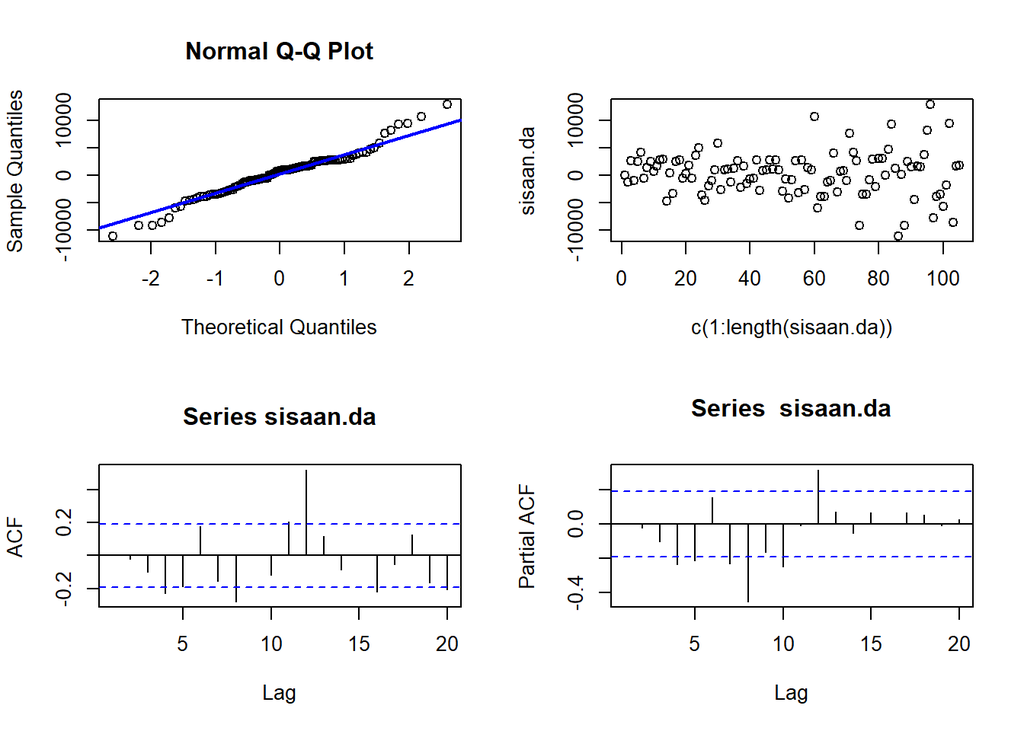

```r
#Eksplorasi
sisaan.da <- model4.da$residuals
par(mfrow=c(2,2))
qqnorm(sisaan.da)
qqline(sisaan.da, col = "blue", lwd = 2)
plot(c(1:length(sisaan.da)),sisaan.da)
acf(sisaan.da)
pacf(sisaan.da)
```

```r
par(mfrow = c(1,1))
```

### Uji Formal

```r
#1) Sisaan Menyebar Normal
tseries::jarque.bera.test(sisaan.da)  #tak tolak H0 < sisaan tidak menyebar normal
```

```
##
##  Jarque Bera Test
##
## data:  sisaan.da
## X-squared = 6.6939, df = 2, p-value = 0.03519
```

Selain dengan eksplorasi, asumsi tersebut dapat diuji menggunakan uji formal. Pada tahapan ini uji formal yang digunakan untuk normalitas adalah uji Jarque Bera . Hipotesis pada uji Jarque Bera adalah sebagai berikut.

$H_0$ : Sisaan menyebar normal

$H_1$ : Sisaan tidak menyebar normal

```r
#2) Sisaan saling bebas/tidak ada autokorelasi
Box.test(sisaan.da, type = "Ljung")  #tak tolak H0 > sisaan saling bebas
```

```
##
##  Box-Ljung test
##
## data:  sisaan.da
## X-squared = 0.0014303, df = 1, p-value = 0.9698
```

Selanjutnya akan dilakukan uji formal untuk kebebasan sisaan menggunakan uji Ljung-Box. Hipotesis yang digunakan adalah sebagai berikut.

$H_0$ : Sisaan saling bebas

$H_1$ : Sisaan tidak tidak saling bebas

```r
#3) Sisaan homogen
Box.test((sisaan.da)^2, type = "Ljung")  #tak tolak H0 < sisaan homogen
```

```
##
##  Box-Ljung test
##
## data:  (sisaan.da)^2
## X-squared = 4.309, df = 1, p-value = 0.03791
```

Hipotesis yang digunakan untuk uji kehomogenan ragam adalah sebagai berikut.

$H_0$ : Ragam sisaan homogen

$H_1$ : Ragam sisaan tidak homogen

Berdasarkan uji Ljung-Box terhadap sisaan kuadrat tersebut, didapat *p-value* sebesar 0.03791 yang lebih kecil dari taraf nyata 5% sehingga tolak $H_0$ dan menandakan bahwa ragam sisaan tidak homogen.

```r
#4) Nilai tengah sisaan sama dengan nol
t.test(sisaan.da, mu = 0, conf.level = 0.95)  #tak tolak h0 > nilai tengah sisaan sama dengan 0
```

```
##
##  One Sample t-test
##
## data:  sisaan.da
## t = 0.73754, df = 104, p-value = 0.4625
## alternative hypothesis: true mean is not equal to 0
## 95 percent confidence interval:
##  -487.907 1065.744
## sample estimates:
## mean of x
##  288.9185
```

Terakhir, dengan uji-t, akan dicek apakah nilai tengah sisaan sama dengan nol. Hipotesis yang diujikan sebagai berikut.

$H_0$ : nilai tengah sisaan sama dengan 0

$H_1$ : nilai tengah sisaan tidak sama dengan 0

Berdasarkan uji-ttersebut, didapat *p-value* sebesar 0.4625 yang lebih besar dari taraf nyata 5% sehingga tak tolak $H_0$ dan menandakan bahwa nilai tengah sisaan sama dengan nol. Hal ini sama dengan hasil eksplorasi.

## Overfitting

Tahapan selanjutnya adalah *overfitting* dilakukan dengan menaikkan orde AR(p) dan MA(q) dari model ARIMA(2,1,2) untuk melihat apakah terdapat model lain yang lebih baik dari model saat ini. Kandidat model *overfitting* adalah ARIMA(3,1,2) dan ARIMA(2,1,3).

### Model ARIMA(3,1,2)

```r
model.overfit1=Arima(train.diff, order=c(3,1,2),method="ML")
summary(model.overfit1) #2038.03
```

```
## Series: train.diff
## ARIMA(3,1,2)
##
## Coefficients:
##           ar1      ar2     ar3      ma1      ma2
##       -0.3789  -0.2394  0.1063  -0.5142  -0.4858
## s.e.   0.2002   0.1032  0.1194   0.1802   0.1789
##
## sigma^2 = 16922761:  log likelihood = -1013.01
## AIC=2038.03   AICc=2038.9   BIC=2053.9
##
## Training set error measures:
##                    ME     RMSE      MAE       MPE     MAPE      MASE
## Training set 274.5238 3994.464 2975.148 -2483.256 2729.907 0.6546673
##                     ACF1
## Training set 0.008051894
```

```r
lmtest::coeftest(model.overfit1) #ar1 dan ar3 tidak signifikan
```

```
##
## z test of coefficients:
##
##     Estimate Std. Error z value Pr(>|z|)
## ar1 -0.37893    0.20024 -1.8924 0.058442 .
## ar2 -0.23940    0.10317 -2.3203 0.020323 *
## ar3  0.10632    0.11938  0.8906 0.373127
## ma1 -0.51423    0.18023 -2.8532 0.004328 **
## ma2 -0.48577    0.17887 -2.7158 0.006612 **
## ---
## Signif. codes:  0 '***' 0.001 '**' 0.01 '*' 0.05 '.' 0.1 ' ' 1
```

### Model ARIMA(2,1,3)

```r
model.overfit2=Arima(train.diff, order=c(2,1,3),method="ML")
summary(model.overfit2) #2019.41
```

```
## Series: train.diff
## ARIMA(2,1,3)
##
## Coefficients:
##           ar1      ar2     ma1      ma2      ma3
##       -1.0049  -0.9804  0.0728  -0.1813  -0.8915
## s.e.   0.0329   0.0237  0.0905   0.0948   0.0557
##
## sigma^2 = 13806197:  log likelihood = -1003.7
## AIC=2019.41   AICc=2020.27   BIC=2035.27
##
## Training set error measures:
##                    ME     RMSE      MAE       MPE     MAPE      MASE      ACF1
## Training set 247.5603 3607.946 2639.201 -1893.645 2143.475 0.5807438 0.1594988
```

```r
lmtest::coeftest(model.overfit2) #ma1 dan ma2 tidak signifikan
```

```
##
## z test of coefficients:
##
##      Estimate Std. Error  z value Pr(>|z|)
## ar1 -1.004934   0.032881 -30.5630  < 2e-16 ***
## ar2 -0.980361   0.023729 -41.3154  < 2e-16 ***
## ma1  0.072771   0.090465   0.8044  0.42116
## ma2 -0.181302   0.094845  -1.9116  0.05593 .
## ma3 -0.891456   0.055734 -15.9948  < 2e-16 ***
## ---
## Signif. codes:  0 '***' 0.001 '**' 0.01 '*' 0.05 '.' 0.1 ' ' 1
```

```r
#model yang dipilih adalah model awal, yaitu ARIMA(2,1,2)
```

## Peramalan

```r
#---FORECAST---#
ramalan.da <- forecast::forecast(model4.da, h = 26)
ramalan.da
```

```
##     Point Forecast     Lo 80    Hi 80     Lo 95    Hi 95
## 107   -1179.220086 -6464.152 4105.712 -9261.826 6903.386
## 108    -825.791158 -6136.321 4484.739 -8947.546 7295.964
## 109    1001.739974 -4541.813 6545.293 -7476.393 9479.873
## 110       1.163169 -5589.946 5592.272 -8549.700 8552.026
## 111       9.304452 -5583.446 5602.055 -8544.070 8562.679
## 112     272.451382 -5323.203 5868.105 -8285.363 8830.266
## 113     139.793215 -5457.278 5736.864 -8420.188 8699.775
## 114     135.305092 -5461.938 5732.548 -8424.939 8695.550
## 115     172.954265 -5424.120 5770.029 -8387.032 8732.941
## 116     155.483985 -5441.694 5752.662 -8404.661 8715.629
## 117     154.093356 -5443.110 5751.297 -8406.090 8714.277
## 118     159.448001 -5437.720 5756.616 -8400.682 8719.578
## 119     157.164183 -5440.016 5754.344 -8402.984 8717.313
## 120     156.866788 -5440.317 5754.051 -8403.288 8717.021
## 121     157.624102 -5439.555 5754.803 -8402.523 8717.771
## 122     157.327993 -5439.853 5754.509 -8402.821 8717.477
## 123     157.272597 -5439.909 5754.454 -8402.877 8717.423
## 124     157.379136 -5439.801 5754.560 -8402.770 8717.528
## 125     157.341100 -5439.840 5754.522 -8402.808 8717.490
## 126     157.331511 -5439.849 5754.512 -8402.818 8717.481
## 127     157.346422 -5439.834 5754.527 -8402.803 8717.496
## 128     157.341589 -5439.839 5754.522 -8402.808 8717.491
## 129     157.340004 -5439.841 5754.521 -8402.809 8717.489
## 130     157.342081 -5439.839 5754.523 -8402.807 8717.491
## 131     157.341474 -5439.839 5754.522 -8402.808 8717.491
## 132     157.341220 -5439.840 5754.522 -8402.808 8717.491
```

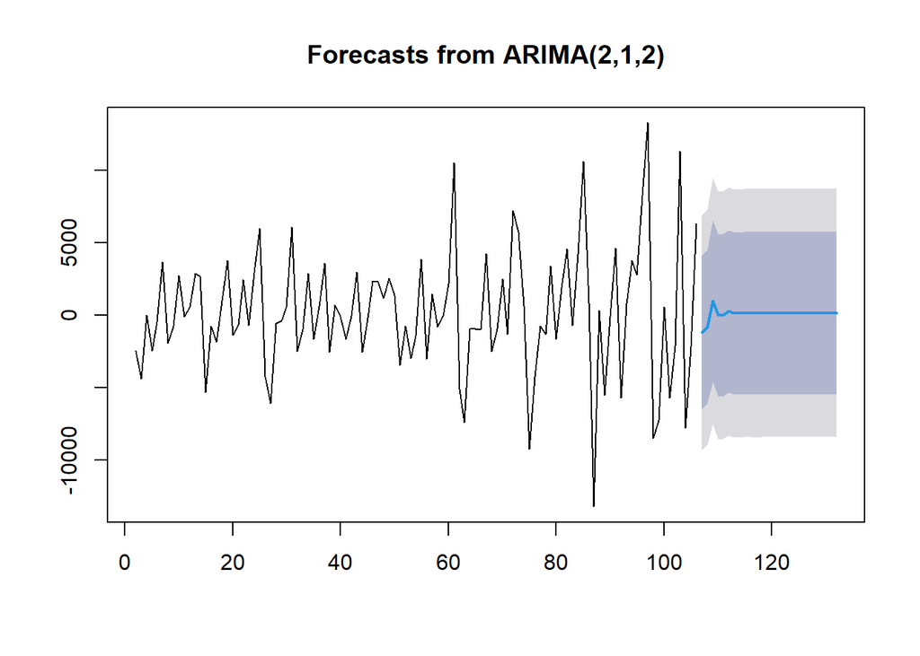

```r
data.ramalan.da <- ramalan.da$mean
plot(ramalan.da)
```

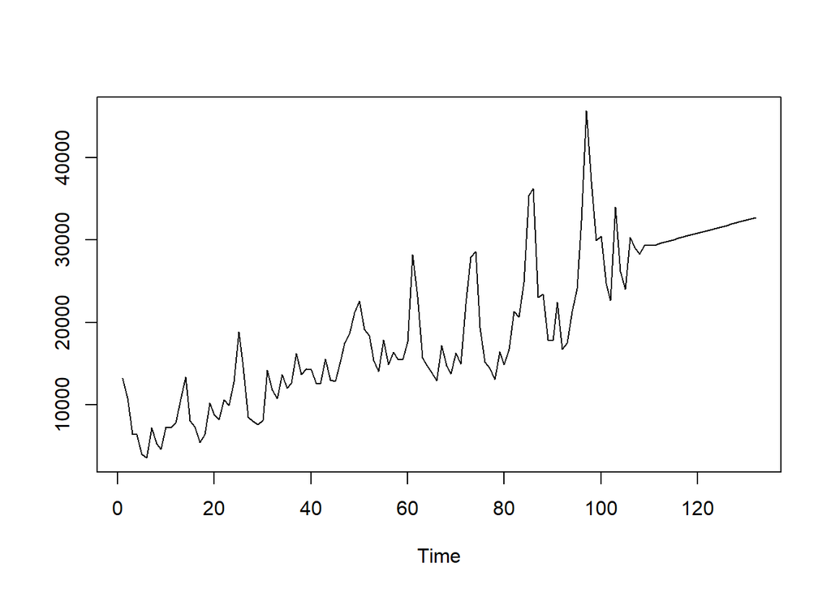

```r
pt_1 <- train.ts[106] #nilai akhir data latih
hasil.forc.Diff <- data.ramalan.da
hasil <- diffinv(hasil.forc.Diff, differences = 1) + pt_1

#has.1 sama hasilnta dengan: cumsum(c(pt_1,hasil.forc.Diff))
ts.plot(train.ts,hasil)
```

```r
perbandingan.da<-matrix(data=c(head(test.ts, n=26), hasil[-1]),
                     nrow = 26, ncol = 2)
colnames(perbandingan.da)<-c("Aktual","Hasil Forecast")
perbandingan.da
```

```
##       Aktual Hasil Forecast
##  [1,]  26439       29138.78
##  [2,]  32959       28312.99
##  [3,]  43647       29314.73
##  [4,]  45129       29315.89
##  [5,]  33745       29325.20
##  [6,]  29896       29597.65
##  [7,]  22655       29737.44
##  [8,]  21210       29872.75
##  [9,]  32686       30045.70
## [10,]  27857       30201.18
## [11,]  23826       30355.28
## [12,]  31235       30514.73
## [13,]  30048       30671.89
## [14,]  37872       30828.76
## [15,]  50330       30986.38
## [16,]  47541       31143.71
## [17,]  31185       31300.98
## [18,]  31263       31458.36
## [19,]  32392       31615.70
## [20,]  29729       31773.03
## [21,]  36012       31930.38
## [22,]  33170       32087.72
## [23,]  30961       32245.06
## [24,]  38057       32402.40
## [25,]  37204       32559.74
## [26,]  39130       32717.09
```

```r
accuracy(ts(hasil[-1]), head(test.ts, n=26))
```

```
##                ME     RMSE      MAE      MPE     MAPE      ACF1 Theil's U
## Test set 2950.942 7587.468 5380.307 4.864096 15.03574 0.5171162  1.003985
```

Dari hasil diperoleh nilai MAPE 15.03574 baik untuk menggambarkan model deret waktu.